# Risk Factor Analysis

## Outcome Variable

**Outcome Variable:** ever_stunted

## Predictor Variables

**Intervention Variable:** mwtkg

**Adjustment Set:**

- arm
- W_mage
- meducyrs
- feducyrs
- single
- brthmon
- delta_W_mage
- delta_meducyrs
- delta_feducyrs
- delta_single
- delta_brthmon

## Stratifying Variables

The analysis was stratified on these variable(s):

- agecat
- studyid
- country

## Data Summary

| agecat | studyid | country | mwtkg | ever_stunted | n_cell | n |
| --- | --- | --- | --- | --- | --- | --- |
| 0-6 months | ki0047075b-MAL-ED | BANGLADESH | >=57.5 | 0 | 44 | 254 |
| 0-6 months | ki0047075b-MAL-ED | BANGLADESH | >=57.5 | 1 | 7 | 254 |
| 0-6 months | ki0047075b-MAL-ED | BANGLADESH | <42.5 | 0 | 46 | 254 |
| 0-6 months | ki0047075b-MAL-ED | BANGLADESH | <42.5 | 1 | 9 | 254 |
| 0-6 months | ki0047075b-MAL-ED | BANGLADESH | [42.5-50) | 0 | 71 | 254 |
| 0-6 months | ki0047075b-MAL-ED | BANGLADESH | [42.5-50) | 1 | 18 | 254 |
| 0-6 months | ki0047075b-MAL-ED | BANGLADESH | [50-57.5) | 0 | 50 | 254 |
| 0-6 months | ki0047075b-MAL-ED | BANGLADESH | [50-57.5) | 1 | 9 | 254 |
| 0-6 months | ki0047075b-MAL-ED | BRAZIL | >=57.5 | 0 | 131 | 221 |
| 0-6 months | ki0047075b-MAL-ED | BRAZIL | >=57.5 | 1 | 13 | 221 |
| 0-6 months | ki0047075b-MAL-ED | BRAZIL | <42.5 | 0 | 11 | 221 |
| 0-6 months | ki0047075b-MAL-ED | BRAZIL | <42.5 | 1 | 3 | 221 |
| 0-6 months | ki0047075b-MAL-ED | BRAZIL | [42.5-50) | 0 | 17 | 221 |
| 0-6 months | ki0047075b-MAL-ED | BRAZIL | [42.5-50) | 1 | 2 | 221 |
| 0-6 months | ki0047075b-MAL-ED | BRAZIL | [50-57.5) | 0 | 40 | 221 |
| 0-6 months | ki0047075b-MAL-ED | BRAZIL | [50-57.5) | 1 | 4 | 221 |
| 0-6 months | ki0047075b-MAL-ED | INDIA | >=57.5 | 0 | 40 | 242 |
| 0-6 months | ki0047075b-MAL-ED | INDIA | >=57.5 | 1 | 4 | 242 |
| 0-6 months | ki0047075b-MAL-ED | INDIA | <42.5 | 0 | 36 | 242 |
| 0-6 months | ki0047075b-MAL-ED | INDIA | <42.5 | 1 | 11 | 242 |
| 0-6 months | ki0047075b-MAL-ED | INDIA | [42.5-50) | 0 | 62 | 242 |
| 0-6 months | ki0047075b-MAL-ED | INDIA | [42.5-50) | 1 | 14 | 242 |
| 0-6 months | ki0047075b-MAL-ED | INDIA | [50-57.5) | 0 | 63 | 242 |
| 0-6 months | ki0047075b-MAL-ED | INDIA | [50-57.5) | 1 | 12 | 242 |
| 0-6 months | ki0047075b-MAL-ED | NEPAL | >=57.5 | 0 | 78 | 238 |
| 0-6 months | ki0047075b-MAL-ED | NEPAL | >=57.5 | 1 | 9 | 238 |
| 0-6 months | ki0047075b-MAL-ED | NEPAL | <42.5 | 0 | 2 | 238 |
| 0-6 months | ki0047075b-MAL-ED | NEPAL | <42.5 | 1 | 0 | 238 |
| 0-6 months | ki0047075b-MAL-ED | NEPAL | [42.5-50) | 0 | 39 | 238 |
| 0-6 months | ki0047075b-MAL-ED | NEPAL | [42.5-50) | 1 | 11 | 238 |

[output cut: 346 more lines]

The following strata were considered:

- agecat: 0-24 months, studyid: ki0047075b-MAL-ED, country: BANGLADESH
- agecat: 0-24 months, studyid: ki0047075b-MAL-ED, country: BRAZIL
- agecat: 0-24 months, studyid: ki0047075b-MAL-ED, country: INDIA
- agecat: 0-24 months, studyid: ki0047075b-MAL-ED, country: NEPAL
- agecat: 0-24 months, studyid: ki0047075b-MAL-ED, country: PERU
- agecat: 0-24 months, studyid: ki0047075b-MAL-ED, country: SOUTH AFRICA
- agecat: 0-24 months, studyid: ki0047075b-MAL-ED, country: TANZANIA, UNITED REPUBLIC OF
- agecat: 0-24 months, studyid: ki1000304b-SAS-CompFeed, country: INDIA
- agecat: 0-24 months, studyid: ki1017093-NIH-Birth, country: BANGLADESH
- agecat: 0-24 months, studyid: ki1017093b-PROVIDE, country: BANGLADESH
- agecat: 0-24 months, studyid: ki1017093c-NIH-Crypto, country: BANGLADESH
- agecat: 0-24 months, studyid: ki1066203-TanzaniaChild2, country: TANZANIA, UNITED REPUBLIC OF
- agecat: 0-24 months, studyid: ki1112895-iLiNS-Zinc, country: BURKINA FASO
- agecat: 0-24 months, studyid: ki1119695-PROBIT, country: BELARUS
- agecat: 0-24 months, studyid: ki1126311-ZVITAMBO, country: ZIMBABWE
- agecat: 0-24 months, studyid: ki1148112-LCNI-5, country: MALAWI
- agecat: 0-6 months, studyid: ki0047075b-MAL-ED, country: BANGLADESH
- agecat: 0-6 months, studyid: ki0047075b-MAL-ED, country: BRAZIL
- agecat: 0-6 months, studyid: ki0047075b-MAL-ED, country: INDIA
- agecat: 0-6 months, studyid: ki0047075b-MAL-ED, country: NEPAL
- agecat: 0-6 months, studyid: ki0047075b-MAL-ED, country: PERU
- agecat: 0-6 months, studyid: ki0047075b-MAL-ED, country: SOUTH AFRICA
- agecat: 0-6 months, studyid: ki0047075b-MAL-ED, country: TANZANIA, UNITED REPUBLIC OF
- agecat: 0-6 months, studyid: ki1000304b-SAS-CompFeed, country: INDIA
- agecat: 0-6 months, studyid: ki1017093-NIH-Birth, country: BANGLADESH
- agecat: 0-6 months, studyid: ki1017093b-PROVIDE, country: BANGLADESH
- agecat: 0-6 months, studyid: ki1017093c-NIH-Crypto, country: BANGLADESH
- agecat: 0-6 months, studyid: ki1066203-TanzaniaChild2, country: TANZANIA, UNITED REPUBLIC OF
- agecat: 0-6 months, studyid: ki1119695-PROBIT, country: BELARUS
- agecat: 0-6 months, studyid: ki1126311-ZVITAMBO, country: ZIMBABWE
- agecat: 0-6 months, studyid: ki1148112-LCNI-5, country: MALAWI
- agecat: 6-24 months, studyid: ki0047075b-MAL-ED, country: BANGLADESH
- agecat: 6-24 months, studyid: ki0047075b-MAL-ED, country: BRAZIL
- agecat: 6-24 months, studyid: ki0047075b-MAL-ED, country: INDIA
- agecat: 6-24 months, studyid: ki0047075b-MAL-ED, country: NEPAL
- agecat: 6-24 months, studyid: ki0047075b-MAL-ED, country: PERU
- agecat: 6-24 months, studyid: ki0047075b-MAL-ED, country: SOUTH AFRICA
- agecat: 6-24 months, studyid: ki0047075b-MAL-ED, country: TANZANIA, UNITED REPUBLIC OF
- agecat: 6-24 months, studyid: ki1000304b-SAS-CompFeed, country: INDIA
- agecat: 6-24 months, studyid: ki1017093-NIH-Birth, country: BANGLADESH
- agecat: 6-24 months, studyid: ki1017093b-PROVIDE, country: BANGLADESH
- agecat: 6-24 months, studyid: ki1017093c-NIH-Crypto, country: BANGLADESH
- agecat: 6-24 months, studyid: ki1066203-TanzaniaChild2, country: TANZANIA, UNITED REPUBLIC OF
- agecat: 6-24 months, studyid: ki1112895-iLiNS-Zinc, country: BURKINA FASO
- agecat: 6-24 months, studyid: ki1119695-PROBIT, country: BELARUS
- agecat: 6-24 months, studyid: ki1126311-ZVITAMBO, country: ZIMBABWE
- agecat: 6-24 months, studyid: ki1148112-LCNI-5, country: MALAWI

### Dropped Strata

Some strata were dropped due to rare outcomes:

- agecat: 0-6 months, studyid: ki0047075b-MAL-ED, country: BRAZIL
- agecat: 0-6 months, studyid: ki0047075b-MAL-ED, country: INDIA
- agecat: 0-6 months, studyid: ki0047075b-MAL-ED, country: NEPAL
- agecat: 0-6 months, studyid: ki0047075b-MAL-ED, country: PERU
- agecat: 0-6 months, studyid: ki0047075b-MAL-ED, country: SOUTH AFRICA
- agecat: 0-6 months, studyid: ki0047075b-MAL-ED, country: TANZANIA, UNITED REPUBLIC OF
- agecat: 0-6 months, studyid: ki1066203-TanzaniaChild2, country: TANZANIA, UNITED REPUBLIC OF
- agecat: 0-6 months, studyid: ki1119695-PROBIT, country: BELARUS
- agecat: 6-24 months, studyid: ki0047075b-MAL-ED, country: BRAZIL
- agecat: 6-24 months, studyid: ki0047075b-MAL-ED, country: NEPAL
- agecat: 6-24 months, studyid: ki0047075b-MAL-ED, country: PERU
- agecat: 6-24 months, studyid: ki0047075b-MAL-ED, country: SOUTH AFRICA
- agecat: 6-24 months, studyid: ki0047075b-MAL-ED, country: TANZANIA, UNITED REPUBLIC OF
- agecat: 6-24 months, studyid: ki1119695-PROBIT, country: BELARUS
- agecat: 0-24 months, studyid: ki0047075b-MAL-ED, country: BRAZIL
- agecat: 0-24 months, studyid: ki0047075b-MAL-ED, country: NEPAL
- agecat: 0-24 months, studyid: ki0047075b-MAL-ED, country: SOUTH AFRICA
- agecat: 0-24 months, studyid: ki0047075b-MAL-ED, country: TANZANIA, UNITED REPUBLIC OF

## Methods Detail

We’re interested in the causal parameters $E[Y_a]$ for all values of $a \in \mathcal{A}$. These parameters represent the mean outcome if, possibly contrary to fact, we intervened to set all units to have $A=a$. Under the randomization and positivity assumptions, these are identified by the statistical parameters $\psi_a=E_W[E_{Y|A,W}(Y|A=a,W)]$. In addition, we’re interested in the mean of $Y$, $E[Y]$ under no intervention (the observed mean). We will estimate these parameters by using SuperLearner to fit the relevant likelihood factors – $E_{Y|A,W}(Y|A=a,W)$ and $p(A=a|W)$, and then updating our likelihood fit using a joint TMLE.

For unadjusted analyses ($W=\{\}$), initial likelihoods were estimated using Lrnr_glm to estimate the simple $E(Y|A)$ and Lrnr_mean to estimate $p(A)$. For adjusted analyses, a small library containing Lrnr_glmnet, Lrnr_xgboost, and Lrnr_mean was used.

Having estimated these parameters, we will then use the delta method to estimate relative risks and attributable risks relative to a prespecified baseline level of $A$.

# Results Detail

## Results Plots

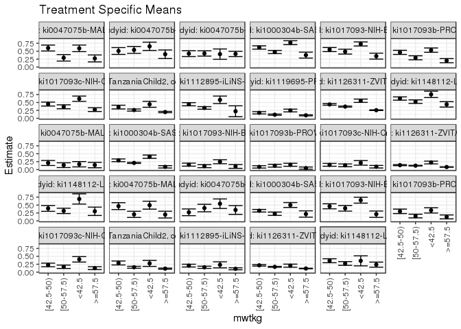

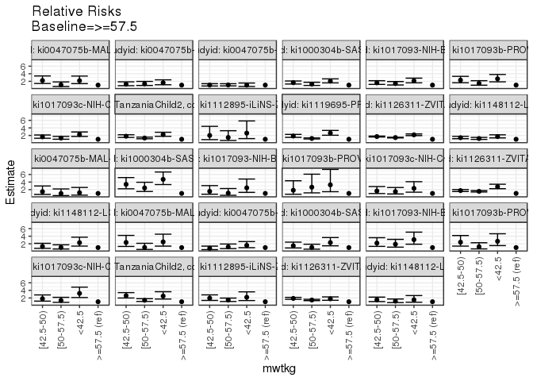

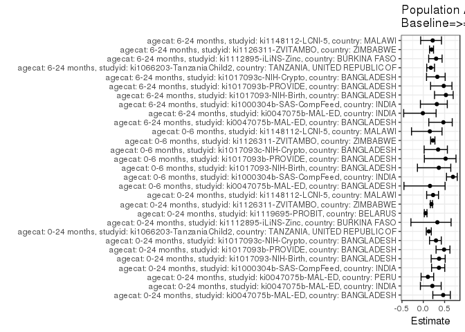

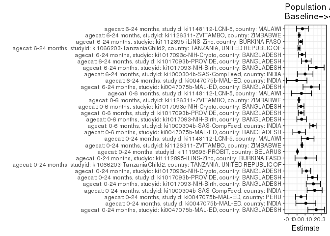

## Results Table

### Parameter: TSM

| agecat | studyid | country | intervention_level | baseline_level | estimate | ci_lower | ci_upper |
| --- | --- | --- | --- | --- | --- | --- | --- |
| 0-24 months | ki0047075b-MAL-ED | BANGLADESH | >=57.5 | NA | 0.2707376 | 0.1604855 | 0.3809896 |
| 0-24 months | ki0047075b-MAL-ED | BANGLADESH | <42.5 | NA | 0.5889790 | 0.4843379 | 0.6936202 |
| 0-24 months | ki0047075b-MAL-ED | BANGLADESH | [42.5-50) | NA | 0.5994521 | 0.5056400 | 0.6932642 |
| 0-24 months | ki0047075b-MAL-ED | BANGLADESH | [50-57.5) | NA | 0.2897651 | 0.1872926 | 0.3922377 |
| 0-24 months | ki0047075b-MAL-ED | INDIA | >=57.5 | NA | 0.4033555 | 0.2683190 | 0.5383919 |
| 0-24 months | ki0047075b-MAL-ED | INDIA | <42.5 | NA | 0.6535617 | 0.5226911 | 0.7844323 |
| 0-24 months | ki0047075b-MAL-ED | INDIA | [42.5-50) | NA | 0.5050015 | 0.3969664 | 0.6130367 |
| 0-24 months | ki0047075b-MAL-ED | INDIA | [50-57.5) | NA | 0.5398381 | 0.4313216 | 0.6483547 |
| 0-24 months | ki0047075b-MAL-ED | PERU | >=57.5 | NA | 0.4121821 | 0.3287558 | 0.4956084 |
| 0-24 months | ki0047075b-MAL-ED | PERU | <42.5 | NA | 0.4061134 | 0.2434558 | 0.5687709 |
| 0-24 months | ki0047075b-MAL-ED | PERU | [42.5-50) | NA | 0.4223296 | 0.3292164 | 0.5154428 |
| 0-24 months | ki0047075b-MAL-ED | PERU | [50-57.5) | NA | 0.4279598 | 0.3426300 | 0.5132897 |
| 0-24 months | ki1000304b-SAS-CompFeed | INDIA | >=57.5 | NA | 0.3751783 | 0.2821337 | 0.4682229 |
| 0-24 months | ki1000304b-SAS-CompFeed | INDIA | <42.5 | NA | 0.7687536 | 0.7077626 | 0.8297445 |
| 0-24 months | ki1000304b-SAS-CompFeed | INDIA | [42.5-50) | NA | 0.6164282 | 0.5644345 | 0.6684219 |
| 0-24 months | ki1000304b-SAS-CompFeed | INDIA | [50-57.5) | NA | 0.4733301 | 0.4239352 | 0.5227250 |
| 0-24 months | ki1017093-NIH-Birth | BANGLADESH | >=57.5 | NA | 0.3431791 | 0.2490718 | 0.4372865 |
| 0-24 months | ki1017093-NIH-Birth | BANGLADESH | <42.5 | NA | 0.7292064 | 0.6643683 | 0.7940446 |
| 0-24 months | ki1017093-NIH-Birth | BANGLADESH | [42.5-50) | NA | 0.5502814 | 0.4854998 | 0.6150629 |
| 0-24 months | ki1017093-NIH-Birth | BANGLADESH | [50-57.5) | NA | 0.4857316 | 0.4087274 | 0.5627359 |
| 0-24 months | ki1017093b-PROVIDE | BANGLADESH | >=57.5 | NA | 0.1999101 | 0.1333893 | 0.2664310 |
| 0-24 months | ki1017093b-PROVIDE | BANGLADESH | <42.5 | NA | 0.5323020 | 0.4638171 | 0.6007869 |
| 0-24 months | ki1017093b-PROVIDE | BANGLADESH | [42.5-50) | NA | 0.4616944 | 0.3961910 | 0.5271978 |
| 0-24 months | ki1017093b-PROVIDE | BANGLADESH | [50-57.5) | NA | 0.2897319 | 0.2255165 | 0.3539474 |
| 0-24 months | ki1017093c-NIH-Crypto | BANGLADESH | >=57.5 | NA | 0.2733986 | 0.2135836 | 0.3332136 |
| 0-24 months | ki1017093c-NIH-Crypto | BANGLADESH | <42.5 | NA | 0.6184648 | 0.5352471 | 0.7016824 |
| 0-24 months | ki1017093c-NIH-Crypto | BANGLADESH | [42.5-50) | NA | 0.4493110 | 0.3869560 | 0.5116661 |
| 0-24 months | ki1017093c-NIH-Crypto | BANGLADESH | [50-57.5) | NA | 0.3631926 | 0.3009280 | 0.4254572 |
| 0-24 months | ki1066203-TanzaniaChild2 | TANZANIA, UNITED REPUBLIC OF | >=57.5 | NA | 0.1965486 | 0.1763996 | 0.2166977 |
| 0-24 months | ki1066203-TanzaniaChild2 | TANZANIA, UNITED REPUBLIC OF | <42.5 | NA | 0.4414452 | 0.3472839 | 0.5356065 |

[output cut: 86 more lines]

### Parameter: E(Y)

| agecat | studyid | country | intervention_level | baseline_level | estimate | ci_lower | ci_upper |
| --- | --- | --- | --- | --- | --- | --- | --- |
| 0-24 months | ki0047075b-MAL-ED | BANGLADESH | NA | NA | 0.5078740 | 0.4462707 | 0.5694773 |
| 0-24 months | ki0047075b-MAL-ED | INDIA | NA | NA | 0.5123967 | 0.4492899 | 0.5755035 |
| 0-24 months | ki0047075b-MAL-ED | PERU | NA | NA | 0.4620690 | 0.4045891 | 0.5195488 |
| 0-24 months | ki1000304b-SAS-CompFeed | INDIA | NA | NA | 0.5931308 | 0.5521428 | 0.6341188 |
| 0-24 months | ki1017093-NIH-Birth | BANGLADESH | NA | NA | 0.5453100 | 0.5063654 | 0.5842547 |
| 0-24 months | ki1017093b-PROVIDE | BANGLADESH | NA | NA | 0.3901345 | 0.3531446 | 0.4271245 |
| 0-24 months | ki1017093c-NIH-Crypto | BANGLADESH | NA | NA | 0.3894040 | 0.3545991 | 0.4242088 |
| 0-24 months | ki1066203-TanzaniaChild2 | TANZANIA, UNITED REPUBLIC OF | NA | NA | 0.2261905 | 0.2092792 | 0.2431017 |
| 0-24 months | ki1112895-iLiNS-Zinc | BURKINA FASO | NA | NA | 0.3314448 | 0.2804289 | 0.3824606 |
| 0-24 months | ki1119695-PROBIT | BELARUS | NA | NA | 0.0989689 | 0.0826855 | 0.1152523 |
| 0-24 months | ki1126311-ZVITAMBO | ZIMBABWE | NA | NA | 0.3160478 | 0.3074385 | 0.3246572 |
| 0-24 months | ki1148112-LCNI-5 | MALAWI | NA | NA | 0.5715990 | 0.5380750 | 0.6051231 |
| 0-6 months | ki0047075b-MAL-ED | BANGLADESH | NA | NA | 0.1692913 | 0.1230820 | 0.2155007 |
| 0-6 months | ki1000304b-SAS-CompFeed | INDIA | NA | NA | 0.2839179 | 0.2547416 | 0.3130943 |
| 0-6 months | ki1017093-NIH-Birth | BANGLADESH | NA | NA | 0.1573927 | 0.1289105 | 0.1858749 |
| 0-6 months | ki1017093b-PROVIDE | BANGLADESH | NA | NA | 0.0971599 | 0.0747000 | 0.1196199 |
| 0-6 months | ki1017093c-NIH-Crypto | BANGLADESH | NA | NA | 0.1390729 | 0.1143746 | 0.1637711 |
| 0-6 months | ki1126311-ZVITAMBO | ZIMBABWE | NA | NA | 0.1035038 | 0.0978590 | 0.1091485 |
| 0-6 months | ki1148112-LCNI-5 | MALAWI | NA | NA | 0.3579336 | 0.3007518 | 0.4151153 |
| 6-24 months | ki0047075b-MAL-ED | BANGLADESH | NA | NA | 0.3743590 | 0.3062579 | 0.4424600 |
| 6-24 months | ki0047075b-MAL-ED | INDIA | NA | NA | 0.3402062 | 0.2733649 | 0.4070475 |
| 6-24 months | ki1000304b-SAS-CompFeed | INDIA | NA | NA | 0.3169969 | 0.2870901 | 0.3469036 |
| 6-24 months | ki1017093-NIH-Birth | BANGLADESH | NA | NA | 0.4500000 | 0.4023647 | 0.4976353 |
| 6-24 months | ki1017093b-PROVIDE | BANGLADESH | NA | NA | 0.2394366 | 0.2018814 | 0.2769918 |
| 6-24 months | ki1017093c-NIH-Crypto | BANGLADESH | NA | NA | 0.1887097 | 0.1578857 | 0.2195336 |
| 6-24 months | ki1066203-TanzaniaChild2 | TANZANIA, UNITED REPUBLIC OF | NA | NA | 0.1352097 | 0.1194609 | 0.1509585 |
| 6-24 months | ki1112895-iLiNS-Zinc | BURKINA FASO | NA | NA | 0.1520334 | 0.1259980 | 0.1780689 |
| 6-24 months | ki1126311-ZVITAMBO | ZIMBABWE | NA | NA | 0.1431626 | 0.1356799 | 0.1506454 |
| 6-24 months | ki1148112-LCNI-5 | MALAWI | NA | NA | 0.3044218 | 0.2671963 | 0.3416472 |

### Parameter: RR

| agecat | studyid | country | intervention_level | baseline_level | estimate | ci_lower | ci_upper |
| --- | --- | --- | --- | --- | --- | --- | --- |
| 0-24 months | ki0047075b-MAL-ED | BANGLADESH | >=57.5 | >=57.5 | 1.0000000 | 1.0000000 | 1.000000 |
| 0-24 months | ki0047075b-MAL-ED | BANGLADESH | <42.5 | >=57.5 | 2.1754610 | 1.3958661 | 3.390462 |
| 0-24 months | ki0047075b-MAL-ED | BANGLADESH | [42.5-50) | >=57.5 | 2.2141445 | 1.4317808 | 3.424013 |
| 0-24 months | ki0047075b-MAL-ED | BANGLADESH | [50-57.5) | >=57.5 | 1.0702805 | 0.6256115 | 1.831009 |
| 0-24 months | ki0047075b-MAL-ED | INDIA | >=57.5 | >=57.5 | 1.0000000 | 1.0000000 | 1.000000 |
| 0-24 months | ki0047075b-MAL-ED | INDIA | <42.5 | >=57.5 | 1.6203119 | 1.0972115 | 2.392803 |
| 0-24 months | ki0047075b-MAL-ED | INDIA | [42.5-50) | >=57.5 | 1.2520011 | 0.8414631 | 1.862835 |
| 0-24 months | ki0047075b-MAL-ED | INDIA | [50-57.5) | >=57.5 | 1.3383682 | 0.9064390 | 1.976117 |
| 0-24 months | ki0047075b-MAL-ED | PERU | >=57.5 | >=57.5 | 1.0000000 | 1.0000000 | 1.000000 |
| 0-24 months | ki0047075b-MAL-ED | PERU | <42.5 | >=57.5 | 0.9852765 | 0.6281525 | 1.545436 |
| 0-24 months | ki0047075b-MAL-ED | PERU | [42.5-50) | >=57.5 | 1.0246190 | 0.7601940 | 1.381021 |
| 0-24 months | ki0047075b-MAL-ED | PERU | [50-57.5) | >=57.5 | 1.0382785 | 0.7856267 | 1.372181 |
| 0-24 months | ki1000304b-SAS-CompFeed | INDIA | >=57.5 | >=57.5 | 1.0000000 | 1.0000000 | 1.000000 |
| 0-24 months | ki1000304b-SAS-CompFeed | INDIA | <42.5 | >=57.5 | 2.0490354 | 1.5852112 | 2.648572 |
| 0-24 months | ki1000304b-SAS-CompFeed | INDIA | [42.5-50) | >=57.5 | 1.6430274 | 1.2928970 | 2.087977 |
| 0-24 months | ki1000304b-SAS-CompFeed | INDIA | [50-57.5) | >=57.5 | 1.2616138 | 0.9126553 | 1.743999 |
| 0-24 months | ki1017093-NIH-Birth | BANGLADESH | >=57.5 | >=57.5 | 1.0000000 | 1.0000000 | 1.000000 |
| 0-24 months | ki1017093-NIH-Birth | BANGLADESH | <42.5 | >=57.5 | 2.1248564 | 1.5923700 | 2.835406 |
| 0-24 months | ki1017093-NIH-Birth | BANGLADESH | [42.5-50) | >=57.5 | 1.6034813 | 1.1892108 | 2.162066 |
| 0-24 months | ki1017093-NIH-Birth | BANGLADESH | [50-57.5) | >=57.5 | 1.4153880 | 1.0318735 | 1.941442 |
| 0-24 months | ki1017093b-PROVIDE | BANGLADESH | >=57.5 | >=57.5 | 1.0000000 | 1.0000000 | 1.000000 |
| 0-24 months | ki1017093b-PROVIDE | BANGLADESH | <42.5 | >=57.5 | 2.6627066 | 1.8635009 | 3.804670 |
| 0-24 months | ki1017093b-PROVIDE | BANGLADESH | [42.5-50) | >=57.5 | 2.3095097 | 1.6090707 | 3.314854 |
| 0-24 months | ki1017093b-PROVIDE | BANGLADESH | [50-57.5) | >=57.5 | 1.4493109 | 0.9718081 | 2.161437 |
| 0-24 months | ki1017093c-NIH-Crypto | BANGLADESH | >=57.5 | >=57.5 | 1.0000000 | 1.0000000 | 1.000000 |
| 0-24 months | ki1017093c-NIH-Crypto | BANGLADESH | <42.5 | >=57.5 | 2.2621361 | 1.7499611 | 2.924214 |
| 0-24 months | ki1017093c-NIH-Crypto | BANGLADESH | [42.5-50) | >=57.5 | 1.6434286 | 1.2687937 | 2.128681 |
| 0-24 months | ki1017093c-NIH-Crypto | BANGLADESH | [50-57.5) | >=57.5 | 1.3284365 | 1.0066052 | 1.753164 |
| 0-24 months | ki1066203-TanzaniaChild2 | TANZANIA, UNITED REPUBLIC OF | >=57.5 | >=57.5 | 1.0000000 | 1.0000000 | 1.000000 |
| 0-24 months | ki1066203-TanzaniaChild2 | TANZANIA, UNITED REPUBLIC OF | <42.5 | >=57.5 | 2.2459846 | 1.7726006 | 2.845789 |

[output cut: 86 more lines]

### Parameter: PAR

| agecat | studyid | country | intervention_level | baseline_level | estimate | ci_lower | ci_upper |
| --- | --- | --- | --- | --- | --- | --- | --- |
| 0-24 months | ki0047075b-MAL-ED | BANGLADESH | >=57.5 | NA | 0.2371364 | 0.1343403 | 0.3399326 |
| 0-24 months | ki0047075b-MAL-ED | INDIA | >=57.5 | NA | 0.1090412 | -0.0139005 | 0.2319830 |
| 0-24 months | ki0047075b-MAL-ED | PERU | >=57.5 | NA | 0.0498868 | -0.0186226 | 0.1183963 |
| 0-24 months | ki1000304b-SAS-CompFeed | INDIA | >=57.5 | NA | 0.2179525 | 0.1249691 | 0.3109359 |
| 0-24 months | ki1017093-NIH-Birth | BANGLADESH | >=57.5 | NA | 0.2021309 | 0.1136115 | 0.2906503 |
| 0-24 months | ki1017093b-PROVIDE | BANGLADESH | >=57.5 | NA | 0.1902244 | 0.1263801 | 0.2540687 |
| 0-24 months | ki1017093c-NIH-Crypto | BANGLADESH | >=57.5 | NA | 0.1160054 | 0.0622877 | 0.1697232 |
| 0-24 months | ki1066203-TanzaniaChild2 | TANZANIA, UNITED REPUBLIC OF | >=57.5 | NA | 0.0296419 | 0.0162007 | 0.0430830 |
| 0-24 months | ki1112895-iLiNS-Zinc | BURKINA FASO | >=57.5 | NA | 0.1094241 | -0.0240926 | 0.2429408 |
| 0-24 months | ki1119695-PROBIT | BELARUS | >=57.5 | NA | 0.0055069 | 0.0025846 | 0.0084293 |
| 0-24 months | ki1126311-ZVITAMBO | ZIMBABWE | >=57.5 | NA | 0.0604097 | 0.0523417 | 0.0684776 |
| 0-24 months | ki1148112-LCNI-5 | MALAWI | >=57.5 | NA | 0.1316689 | 0.0531274 | 0.2102105 |
| 0-6 months | ki0047075b-MAL-ED | BANGLADESH | >=57.5 | NA | 0.0265939 | -0.0518947 | 0.1050825 |
| 0-6 months | ki1000304b-SAS-CompFeed | INDIA | >=57.5 | NA | 0.1976189 | 0.1588837 | 0.2363541 |
| 0-6 months | ki1017093-NIH-Birth | BANGLADESH | >=57.5 | NA | 0.0573844 | -0.0018028 | 0.1165716 |
| 0-6 months | ki1017093b-PROVIDE | BANGLADESH | >=57.5 | NA | 0.0508838 | 0.0154238 | 0.0863439 |
| 0-6 months | ki1017093c-NIH-Crypto | BANGLADESH | >=57.5 | NA | 0.0483452 | 0.0105500 | 0.0861405 |
| 0-6 months | ki1126311-ZVITAMBO | ZIMBABWE | >=57.5 | NA | 0.0232445 | 0.0179215 | 0.0285675 |
| 0-6 months | ki1148112-LCNI-5 | MALAWI | >=57.5 | NA | 0.0551491 | -0.0700460 | 0.1803443 |
| 6-24 months | ki0047075b-MAL-ED | BANGLADESH | >=57.5 | NA | 0.1765174 | 0.0741465 | 0.2788883 |
| 6-24 months | ki0047075b-MAL-ED | INDIA | >=57.5 | NA | -0.0035114 | -0.1299256 | 0.1229028 |
| 6-24 months | ki1000304b-SAS-CompFeed | INDIA | >=57.5 | NA | 0.1005603 | 0.0039434 | 0.1971772 |
| 6-24 months | ki1017093-NIH-Birth | BANGLADESH | >=57.5 | NA | 0.2389889 | 0.1428522 | 0.3351256 |
| 6-24 months | ki1017093b-PROVIDE | BANGLADESH | >=57.5 | NA | 0.1147232 | 0.0549373 | 0.1745091 |
| 6-24 months | ki1017093c-NIH-Crypto | BANGLADESH | >=57.5 | NA | 0.0621689 | 0.0204762 | 0.1038616 |
| 6-24 months | ki1066203-TanzaniaChild2 | TANZANIA, UNITED REPUBLIC OF | >=57.5 | NA | 0.0239922 | 0.0114354 | 0.0365491 |
| 6-24 months | ki1112895-iLiNS-Zinc | BURKINA FASO | >=57.5 | NA | 0.0458135 | 0.0215371 | 0.0700898 |
| 6-24 months | ki1126311-ZVITAMBO | ZIMBABWE | >=57.5 | NA | 0.0278214 | 0.0209801 | 0.0346626 |
| 6-24 months | ki1148112-LCNI-5 | MALAWI | >=57.5 | NA | 0.0669855 | -0.0063309 | 0.1403020 |

### Parameter: PAF

| agecat | studyid | country | intervention_level | baseline_level | estimate | ci_lower | ci_upper |
| --- | --- | --- | --- | --- | --- | --- | --- |
| 0-24 months | ki0047075b-MAL-ED | BANGLADESH | >=57.5 | NA | 0.4669198 | 0.2235764 | 0.6339956 |
| 0-24 months | ki0047075b-MAL-ED | INDIA | >=57.5 | NA | 0.2128062 | -0.0676766 | 0.4196052 |
| 0-24 months | ki0047075b-MAL-ED | PERU | >=57.5 | NA | 0.1079641 | -0.0519612 | 0.2435765 |
| 0-24 months | ki1000304b-SAS-CompFeed | INDIA | >=57.5 | NA | 0.3674611 | 0.1940840 | 0.5035395 |
| 0-24 months | ki1017093-NIH-Birth | BANGLADESH | >=57.5 | NA | 0.3706715 | 0.1851572 | 0.5139499 |
| 0-24 months | ki1017093b-PROVIDE | BANGLADESH | >=57.5 | NA | 0.4875867 | 0.2995683 | 0.6251349 |
| 0-24 months | ki1017093c-NIH-Crypto | BANGLADESH | >=57.5 | NA | 0.2979050 | 0.1468475 | 0.4222166 |
| 0-24 months | ki1066203-TanzaniaChild2 | TANZANIA, UNITED REPUBLIC OF | >=57.5 | NA | 0.1310482 | 0.0700825 | 0.1880169 |
| 0-24 months | ki1112895-iLiNS-Zinc | BURKINA FASO | >=57.5 | NA | 0.3301427 | -0.2900142 | 0.6521675 |
| 0-24 months | ki1119695-PROBIT | BELARUS | >=57.5 | NA | 0.0556432 | 0.0237669 | 0.0864787 |
| 0-24 months | ki1126311-ZVITAMBO | ZIMBABWE | >=57.5 | NA | 0.1911409 | 0.1653825 | 0.2161043 |
| 0-24 months | ki1148112-LCNI-5 | MALAWI | >=57.5 | NA | 0.2303519 | 0.0791219 | 0.3567463 |
| 0-6 months | ki0047075b-MAL-ED | BANGLADESH | >=57.5 | NA | 0.1570896 | -0.4535478 | 0.5111974 |
| 0-6 months | ki1000304b-SAS-CompFeed | INDIA | >=57.5 | NA | 0.6960425 | 0.5447252 | 0.7970672 |
| 0-6 months | ki1017093-NIH-Birth | BANGLADESH | >=57.5 | NA | 0.3645938 | -0.1375362 | 0.6450741 |
| 0-6 months | ki1017093b-PROVIDE | BANGLADESH | >=57.5 | NA | 0.5237122 | 0.0252441 | 0.7672750 |
| 0-6 months | ki1017093c-NIH-Crypto | BANGLADESH | >=57.5 | NA | 0.3476253 | 0.0207545 | 0.5653870 |
| 0-6 months | ki1126311-ZVITAMBO | ZIMBABWE | >=57.5 | NA | 0.2245761 | 0.1727567 | 0.2731495 |
| 0-6 months | ki1148112-LCNI-5 | MALAWI | >=57.5 | NA | 0.1540764 | -0.2764315 | 0.4393850 |
| 6-24 months | ki0047075b-MAL-ED | BANGLADESH | >=57.5 | NA | 0.4715191 | 0.1293055 | 0.6792307 |
| 6-24 months | ki0047075b-MAL-ED | INDIA | >=57.5 | NA | -0.0103213 | -0.4596209 | 0.3006751 |
| 6-24 months | ki1000304b-SAS-CompFeed | INDIA | >=57.5 | NA | 0.3172282 | -0.0674419 | 0.5632761 |
| 6-24 months | ki1017093-NIH-Birth | BANGLADESH | >=57.5 | NA | 0.5310865 | 0.2638994 | 0.7012910 |
| 6-24 months | ki1017093b-PROVIDE | BANGLADESH | >=57.5 | NA | 0.4791382 | 0.1713919 | 0.6725870 |
| 6-24 months | ki1017093c-NIH-Crypto | BANGLADESH | >=57.5 | NA | 0.3294420 | 0.0760558 | 0.5133385 |
| 6-24 months | ki1066203-TanzaniaChild2 | TANZANIA, UNITED REPUBLIC OF | >=57.5 | NA | 0.1774446 | 0.0812763 | 0.2635465 |
| 6-24 months | ki1112895-iLiNS-Zinc | BURKINA FASO | >=57.5 | NA | 0.3013380 | 0.1267920 | 0.4409939 |
| 6-24 months | ki1126311-ZVITAMBO | ZIMBABWE | >=57.5 | NA | 0.1943340 | 0.1460348 | 0.2399014 |
| 6-24 months | ki1148112-LCNI-5 | MALAWI | >=57.5 | NA | 0.2200419 | -0.0616112 | 0.4269704 |